# Bài tập 5.7 - Phân tích thành phần chính (dữ liệu stock-price)

## 0.1 Giới thiệu và đề bài

### 0.1.1 Bối cảnh

Dữ liệu ghi nhận **suất sinh lợi theo tuần** (weekly rate of return) của **5 cổ phiếu niêm yết trên Sở giao dịch chứng khoán New York (NYSE)** trong **103 tuần liên tiếp, từ tháng 01/2004 đến tháng 12/2005**. Suất sinh lợi tuần được tính bằng

$$\text{suất sinh lợi tuần} =
\frac{\text{giá đóng cửa tuần này} - \text{giá đóng cửa tuần
trước}}{\text{giá đóng cửa tuần trước}},$$

đã điều chỉnh theo chia tách cổ phiếu và cổ tức. Năm biến gồm:

| Biến | Cổ phiếu | Nhóm ngành |
| --- | --- | --- |
| $x_1$ | JP Morgan | Ngân hàng |
| $x_2$ | Citibank | Ngân hàng |
| $x_3$ | Wells Fargo | Ngân hàng |
| $x_4$ | Royal Dutch Shell | Dầu lửa |
| $x_5$ | ExxonMobil | Dầu lửa |

Quan trắc giữa các tuần được xem là độc lập, nhưng suất sinh lợi của các cổ phiếu **trong cùng một tuần** tương quan với nhau, vì các cổ phiếu cùng phản ứng với tình hình kinh tế chung, và các cổ phiếu cùng ngành còn chịu chung các cú sốc của ngành. Vì vậy 5 biến chứa nhiều thông tin trùng lặp. Phân tích thành phần chính (PCA) được dùng để tìm một số ít tổ hợp tuyến tính không tương quan của 5 suất sinh lợi giải thích được phần lớn biến thiên, và xem các tổ hợp này phản ánh yếu tố gì (thị trường chung, ngành, hay riêng từng công ty).

### 0.1.2 Câu hỏi đặt ra

**Bài 5.7.** Dùng dữ liệu về suất sinh lợi/tuần khảo sát trong ví dụ 5.4 (dữ liệu stock-price).

- **(a)** Xây dựng ma trận hiệp phương sai $\mathbf S$ và các thành phần chính tương ứng.
- **(b)** Tính tỷ số đóng góp vào phương sai suy rộng của ba thành phần chính đầu tiên và giải thích ý nghĩa của nó.
- **(c)** Xây dựng các khoảng tin cậy đồng thời Bonferroni 90% cho các phương sai $\lambda_1,\lambda_2,\lambda_3$ của ba thành phần chính đầu $Y_1, Y_2, Y_3$.
- **(d)** Với kết quả trong các phần a–c, đánh giá xem dữ liệu có thể thu gọn xuống ít hơn 5 chiều không? Giải thích.

## 0.2 Dữ liệu và kiểm tra đầu vào

### 0.2.1 Mô tả dữ liệu

```r
stock <- read.table(file.path(data_dir, "EXo_5_7.DAT"), header = FALSE)
colnames(stock) <- c("JPMorgan", "Citibank", "WellsFargo", "RDShell", "ExxonMobil")
X <- as.matrix(stock)

n <- nrow(X)
p <- ncol(X)
c(n = n, p = p)
```

```
##   n   p
## 103   5
```

```r
str(stock)
```

```
## 'data.frame':    103 obs. of  5 variables:
##  $ JPMorgan  : num  0.01303 0.00849 -0.01792 0.02156 0.01082 ...
##  $ Citibank  : num  -0.00784 0.01669 -0.00864 -0.00349 0.00372 ...
##  $ WellsFargo: num  -0.00319 -0.00621 0.01004 0.01744 -0.01013 ...
##  $ RDShell   : num  -0.0448 0.012 0 -0.0286 0.0292 ...
##  $ ExxonMobil: num  0.00522 0.01349 -0.00614 -0.00695 0.04098 ...
```

```r
head(stock)
```

```
##     JPMorgan   Citibank WellsFargo    RDShell ExxonMobil
## 1  0.0130338 -0.0078431 -0.0031889 -0.0447693  0.0052151
## 2  0.0084862  0.0166886 -0.0062100  0.0119560  0.0134890
## 3 -0.0179153 -0.0086393  0.0100360  0.0000000 -0.0061428
## 4  0.0215589 -0.0034858  0.0174353 -0.0285917 -0.0069534
## 5  0.0108225  0.0037167 -0.0101345  0.0291900  0.0409751
## 6  0.0101713 -0.0121978 -0.0083768  0.0137083  0.0029895
```

Dữ liệu có **n = 103 quan trắc** (tuần) và **p = 5 biến**, sắp theo thứ tự $x_1,\dots,x_5$ như bảng ở mục Bối cảnh. Cả 5 biến đều là biến số liên tục (suất sinh lợi, không có đơn vị).

```r
summary(stock)
```

```
##     JPMorgan            Citibank            WellsFargo
##  Min.   :-0.045867   Min.   :-0.0597924   Min.   :-0.0362141
##  1st Qu.:-0.013564   1st Qu.:-0.0132409   1st Qu.:-0.0080536
##  Median : 0.003363   Median : 0.0017339   Median : 0.0003354
##  Mean   : 0.001063   Mean   : 0.0006554   Mean   : 0.0016261
##  3rd Qu.: 0.016804   3rd Qu.: 0.0140293   3rd Qu.: 0.0100178
##  Max.   : 0.048480   Max.   : 0.0525266   Max.   : 0.0406957
##     RDShell            ExxonMobil
##  Min.   :-0.053948   Min.   :-0.063605
##  1st Qu.:-0.014470   1st Qu.:-0.012539
##  Median : 0.006335   Median : 0.005215
##  Mean   : 0.004049   Mean   : 0.004039
##  3rd Qu.: 0.022237   3rd Qu.: 0.021622
##  Max.   : 0.061994   Max.   : 0.078416
```

Mỗi biến có trung vị và trung bình gần 0, giá trị nhỏ nhất âm và lớn nhất dương — đúng tính chất của suất sinh lợi theo tuần (lên/xuống quanh 0).

```r
colSums(is.na(stock))
```

```
##   JPMorgan   Citibank WellsFargo    RDShell ExxonMobil
##          0          0          0          0          0
```

Không có giá trị thiếu ở biến nào.

### 0.2.2 Giá trị ngoại lai

#### 0.2.2.1 Ngoại lai từng biến (boxplot)

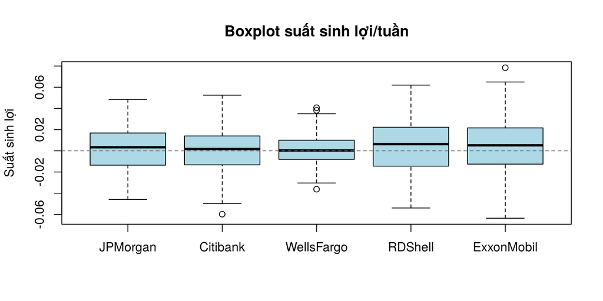

```r
boxplot(stock, col = "lightblue", main = "Boxplot suất sinh lợi/tuần", ylab = "Suất sinh lợi")
abline(h = 0, lty = 2, col = "grey40")
```

#### 0.2.2.2 Giá trị chuẩn hóa từng biến

Tính các giá trị chuẩn hóa $z_{jk}=(x_{jk}-\bar x_k)/\sqrt{s_{kk}}$, $j=1,\dots,n$, $k=1,\dots,5$. Với cỡ mẫu vừa phải, giá trị $|z_{jk}|>3.5$ được xem là lớn bất thường.

```r
Z <- (X - rep(1, n) %*% t(colMeans(X))) / (rep(1, n) %*% t(sqrt(diag(cov(X)))))
round(apply(abs(Z), 2, max), 3)
```

```
##   JPMorgan   Citibank WellsFargo    RDShell ExxonMobil
##      2.278      2.886      2.611      2.158      2.688
```

```r
sum(abs(Z) > 3.5)
```

```
## [1] 0
```

Giá trị chuẩn hóa lớn nhất (trị tuyệt đối) của từng biến đều nhỏ hơn 3.5 (lớn nhất là 2.886) → không có giá trị bất thường theo từng biến.

#### 0.2.2.3 Khoảng cách Mahalanobis (khoảng cách tổng quát bình phương)

Với mỗi quan trắc tính $d_j^2=(\mathbf x_j-\bar{\mathbf x})'\mathbf S^{-1}(\mathbf x_j-\bar{\mathbf x})$, $j=1,\dots,n$. Khi dữ liệu chuẩn $N_5$, $d_j^2$ xấp xỉ $\chi^2_5$, nên khoảng 5% số quan trắc sẽ có $d_j^2$ vượt phân vị $\chi^2_5(0.95)$ ngay cả khi không có ngoại lai; quan trắc ngoại lai được xác định bằng một phân vị cực trị hơn, ở đây dùng $\chi^2_5(0.995)$.

```r
xbar <- colMeans(X)
one  <- rep(1, n)
Xc   <- X - one %*% t(xbar)              # ma trận dữ liệu đã quy tâm
S    <- t(Xc) %*% Xc / (n - 1)           # ma trận hiệp phương sai mẫu S
S_inv <- solve(S)

d2 <- rowSums((Xc %*% S_inv) * Xc)       # d_j^2 cho từng tuần j
nguong_95  <- qchisq(0.95, df = p)
nguong_995 <- qchisq(0.995, df = p)
c(chi2_095 = nguong_95, chi2_0995 = nguong_995)
```

```
##  chi2_095 chi2_0995
##   11.0705   16.7496
```

```r
c(so_tuan_vuot_095 = sum(d2 > nguong_95), ky_vong = 0.05 * n)
```

```
## so_tuan_vuot_095          ky_vong
##             7.00             5.15
```

```r
sum(d2 > nguong_995)
```

```
## [1] 0
```

```r
round(max(d2), 3)
```

```
## [1] 15.507
```

Có 7 tuần có $d_j^2>\chi^2_5(0.95)=$ 11.07, gần với số kỳ vọng $0.05\times103\approx$ 5.2 tuần. Không có tuần nào vượt $\chi^2_5(0.995)=$ 16.75 ($d_j^2$ lớn nhất là 15.51) → **không có quan trắc ngoại lai**; dùng toàn bộ 103 quan trắc để xây dựng $\mathbf S$.

### 0.2.3 Giả định chuẩn nhiều chiều (cần cho câu c)

Khoảng tin cậy cho $\lambda_i$ ở câu (c) giả định mẫu lấy từ $N_5(\boldsymbol\mu,\boldsymbol\Sigma)$. Ta kiểm tra bằng đồ thị chi bình phương (chi-square plot): sắp xếp $d^2_{(1)}\le\dots\le d^2_{(n)}$ và vẽ theo phân vị $\chi^2_5\big((j-\tfrac12)/n\big)$; nếu dữ liệu chuẩn, các điểm nằm gần đường thẳng $y=x$.

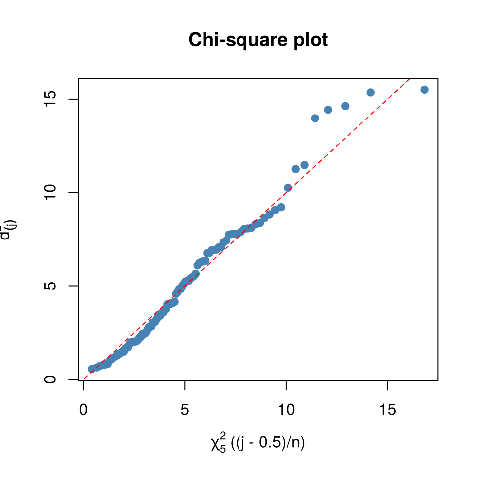

```r
d2_sap_xep <- sort(d2)
q_chi2 <- qchisq((1:n - 0.5) / n, df = p)
plot(q_chi2, d2_sap_xep, pch = 19, col = "steelblue",
     xlab = expression(chi[5]^2 ~ "((j - 0.5)/n)"), ylab = expression(d[(j)]^2),
     main = "Chi-square plot")
abline(0, 1, col = "red", lty = 2)
```

```r
# tỷ lệ d_j^2 nằm dưới trung vị chi^2_5 (kỳ vọng khoảng 50% nếu chuẩn)
mean(d2 <= qchisq(0.5, df = p))
```

```
## [1] 0.5242718
```

Các điểm nằm khá sát đường thẳng đi qua gốc tọa độ với hệ số góc 1, không có dạng cong có hệ thống; chỉ vài điểm ở đuôi trên hơi lệch lên (các tuần biến động mạnh). Tỷ lệ $d_j^2\le\chi^2_5(0.5)$ là 0.524, gần 0.5. → Giả định chuẩn nhiều chiều **chấp nhận được ở mức xấp xỉ**; vì vậy các khoảng tin cậy ở câu (c) được hiểu là **khoảng xấp xỉ** (n = 103 lớn).

## 0.3 Độ lệch chuẩn và tương quan giữa các biến

### 0.3.1 Độ lệch chuẩn từng biến

```r
s_kk <- diag(S)
round(sqrt(s_kk), 5)
```

```
##   JPMorgan   Citibank WellsFargo    RDShell ExxonMobil
##    0.02082    0.02095    0.01497    0.02688    0.02767
```

Độ lệch chuẩn của hai cổ phiếu dầu (≈ 0.0269 và 0.0277) lớn hơn ba cổ phiếu ngân hàng (≈ 0.015 – 0.0209), nhưng cùng bậc độ lớn và **cùng đơn vị**, không bị quá chênh lệch → làm PCA trên $\mathbf S$ (như đề yêu cầu), không cần chuẩn hóa; các biến dầu sẽ có trọng số lớn hơn trong thành phần chính đầu vì phương sai lớn hơn.

### 0.3.2 Ma trận tương quan mẫu R

```r
D_can  <- diag(1 / sqrt(s_kk))          # D^{-1/2}
R <- D_can %*% S %*% D_can
dimnames(R) <- list(colnames(X), colnames(X))
round(R, 4)
```

```
##            JPMorgan Citibank WellsFargo RDShell ExxonMobil
## JPMorgan     1.0000   0.6323     0.5105  0.1146     0.1545
## Citibank     0.6323   1.0000     0.5741  0.3223     0.2127
## WellsFargo   0.5105   0.5741     1.0000  0.1825     0.1462
## RDShell      0.1146   0.3223     0.1825  1.0000     0.6834
## ExxonMobil   0.1545   0.2127     0.1462  0.6834     1.0000
```

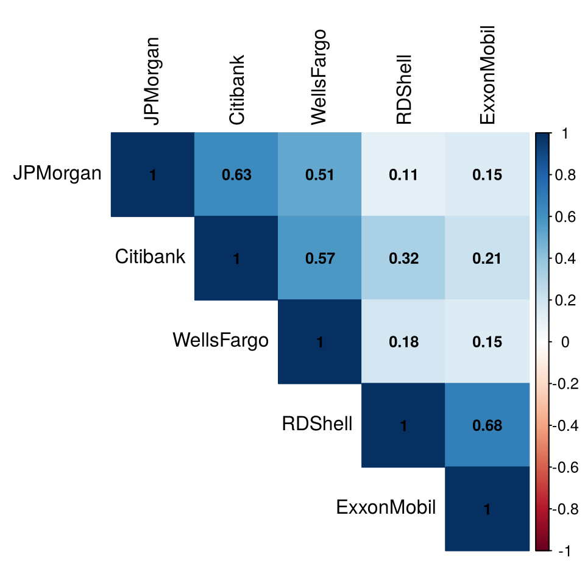

```r
corrplot::corrplot(R, method = "color", type = "upper", addCoef.col = "black",
                   number.cex = 0.8, tl.col = "black")
```

Ba cổ phiếu ngân hàng tương quan với nhau khá cao (0.51–0.63), hai cổ phiếu dầu tương quan với nhau cao nhất (0.68), còn tương quan chéo ngân hàng–dầu thấp (0.11–0.32) → có **hai nhóm biến** rõ rệt. Các biến tương quan dương đáng kể nên PCA có ý nghĩa.

## 0.4 Câu (a) — Ma trận S và các thành phần chính mẫu

### 0.4.1 Vectơ trung bình mẫu và ma trận hiệp phương sai mẫu S

$\bar{\mathbf x}=\frac1n\mathbf X'\mathbf 1$, $\quad\mathbf S=\frac{1}{n-1}(\mathbf X-\mathbf 1\bar{\mathbf x}')'(\mathbf X-\mathbf 1\bar{\mathbf x}')$ (đã tính ở mục Giá trị ngoại lai).

```r
round(xbar, 7)
```

```
##   JPMorgan   Citibank WellsFargo    RDShell ExxonMobil
##  0.0010628  0.0006554  0.0016261  0.0040491  0.0040386
```

```r
dimnames(S) <- list(colnames(X), colnames(X))
S
```

```
##                JPMorgan     Citibank   WellsFargo      RDShell   ExxonMobil
## JPMorgan   4.332695e-04 0.0002756679 1.590265e-04 6.411929e-05 8.896616e-05
## Citibank   2.756679e-04 0.0004387172 1.799737e-04 1.814512e-04 1.232623e-04
## WellsFargo 1.590265e-04 0.0001799737 2.239722e-04 7.341348e-05 6.054612e-05
## RDShell    6.411929e-05 0.0001814512 7.341348e-05 7.224964e-04 5.082772e-04
## ExxonMobil 8.896616e-05 0.0001232623 6.054612e-05 5.082772e-04 7.656742e-04
```

$\bar{\mathbf x}'=$ (0.0011, 0.0007, 0.0016, 0.0040, 0.0040). Ma trận $\mathbf S$ có các phần tử rất nhỏ (bậc $10^{-4}$) vì suất sinh lợi tuần chỉ khoảng vài phần trăm. Trên đường chéo, $s_{44}=$ 0.0007225 và $s_{55}=$ 0.0007657 (dầu) lớn khoảng 1.7 lần $s_{11},s_{22}$ và khoảng 3.2 lần $s_{33}$ (ngân hàng).

### 0.4.2 Các cặp trị riêng – vectơ riêng của S

```r
eig_S <- eigen(S)
lambda_hat <- eig_S$values
V_hat <- eig_S$vectors
dimnames(V_hat) <- list(colnames(X), paste0("v", 1:p))

lambda_hat
```

```
## [1] 0.0013676780 0.0007011596 0.0002538024 0.0001426026 0.0001188868
```

```r
round(V_hat, 4)
```

```
##                v1      v2      v3      v4      v5
## JPMorgan   0.2228  0.6252  0.3261  0.6628  0.1177
## Citibank   0.3073  0.5704 -0.2496 -0.4141 -0.5886
## WellsFargo 0.1548  0.3445 -0.0376 -0.4970  0.7803
## RDShell    0.6390 -0.2479 -0.6425  0.3089  0.1485
## ExxonMobil 0.6509 -0.3218  0.6459 -0.2164 -0.0937
```

$\hat\lambda_1=$ 0.0013677 $\ge\hat\lambda_2=$ 0.00070116 $\ge\hat\lambda_3=$ 0.0002538 $\ge\hat\lambda_4=$ 0.0001426 $\ge\hat\lambda_5=$ 0.00011889 $\ge 0$; năm trị riêng phân biệt.

Kiểm tra $\{\hat{\mathbf v}_1,\dots,\hat{\mathbf v}_5\}$ là cơ sở trực chuẩn ($\hat{\mathbf V}'\hat{\mathbf V}=\mathbf I$) và $\hat{\mathbf V}'\mathbf S\hat{\mathbf V}=\text{diag}(\hat\lambda_1,\dots,\hat\lambda_5)$:

```r
round(t(V_hat) %*% V_hat, 10)
```

```
##    v1 v2 v3 v4 v5
## v1  1  0  0  0  0
## v2  0  1  0  0  0
## v3  0  0  1  0  0
## v4  0  0  0  1  0
## v5  0  0  0  0  1
```

```r
round(t(V_hat) %*% S %*% V_hat, 10)
```

```
##             v1           v2           v3           v4           v5
## v1 0.001367678 0.0000000000 0.0000000000 0.0000000000 0.0000000000
## v2 0.000000000 0.0007011596 0.0000000000 0.0000000000 0.0000000000
## v3 0.000000000 0.0000000000 0.0002538024 0.0000000000 0.0000000000
## v4 0.000000000 0.0000000000 0.0000000000 0.0001426026 0.0000000000
## v5 0.000000000 0.0000000000 0.0000000000 0.0000000000 0.0001188868
```

Ma trận thứ nhất là $\mathbf I_5$, ma trận thứ hai là ma trận chéo với các phần tử chéo đúng bằng $\hat\lambda_i$ → các vectơ riêng trực chuẩn và chéo hóa $\mathbf S$.

### 0.4.3 Các thành phần chính mẫu

Thành phần chính mẫu thứ $i$ là $\hat y_i=\hat{\mathbf v}_i'\mathbf x=\hat v_{i1}x_1+\hat v_{i2}x_2+\dots+\hat v_{i5}x_5$, với $\text{var}(\hat y_i)=\hat\lambda_i$ và $\text{cov}(\hat y_i,\hat y_k)=0$, $i\ne k$:

$$\begin{aligned}
\hat y_1 &= 0.223\,x_1 + 0.307\,x_2 + 0.155\,x_3 + 0.639\,x_4 +
0.651\,x_5\\
\hat y_2 &= 0.625\,x_1 + (0.57)\,x_2 + (0.345)\,x_3 + (-0.248)\,x_4
+ (-0.322)\,x_5\\
\hat y_3 &= 0.326\,x_1 + (-0.25)\,x_2 + (-0.038)\,x_3 +
(-0.642)\,x_4 + (0.646)\,x_5\\
\hat y_4 &= 0.663\,x_1 + (-0.414)\,x_2 + (-0.497)\,x_3 +
(0.309)\,x_4 + (-0.216)\,x_5\\
\hat y_5 &= 0.118\,x_1 + (-0.589)\,x_2 + (0.78)\,x_3 + (0.148)\,x_4
+ (-0.094)\,x_5
\end{aligned}$$

(Vectơ riêng chỉ xác định đến dấu, nên đổi dấu toàn bộ một $\hat{\mathbf v}_i$ vẫn cho cùng thành phần chính.)

Điểm thành phần chính (scores) của từng tuần: $\hat y_{ji}=\hat{\mathbf v}_i'(\mathbf x_j-\bar{\mathbf x})$, tức ma trận $\hat{\mathbf Y}=(\mathbf X-\mathbf 1\bar{\mathbf x}')\hat{\mathbf V}$:

```r
Y_hat <- Xc %*% V_hat
colnames(Y_hat) <- paste0("y", 1:p)
round(head(Y_hat), 5)
```

```
##            y1       y2       y3       y4       y5
## [1,] -0.03112  0.01270  0.03833 -0.00149 -0.00470
## [2,]  0.01657  0.00608 -0.00026  0.00257 -0.01439
## [3,] -0.01500 -0.00999 -0.00816 -0.01196  0.01015
## [4,] -0.02227  0.02753  0.02099 -0.00026  0.01337
## [5,]  0.04140 -0.01432  0.01056  0.01082 -0.00956
## [6,]  0.00202 -0.00714 -0.00033  0.01954  0.00236
```

```r
# ma trận hiệp phương sai của các scores
round(t(Y_hat) %*% Y_hat / (n - 1), 10)
```

```
##             y1           y2           y3           y4           y5
## y1 0.001367678 0.0000000000 0.0000000000 0.0000000000 0.0000000000
## y2 0.000000000 0.0007011596 0.0000000000 0.0000000000 0.0000000000
## y3 0.000000000 0.0000000000 0.0002538024 0.0000000000 0.0000000000
## y4 0.000000000 0.0000000000 0.0000000000 0.0001426026 0.0000000000
## y5 0.000000000 0.0000000000 0.0000000000 0.0000000000 0.0001188868
```

Ma trận hiệp phương sai của các scores là ma trận chéo $\text{diag}(\hat\lambda_1,\dots,\hat\lambda_5)$ → đúng $\text{var}(\hat y_k)=\hat\lambda_k$ và $\text{cov}(\hat y_i,\hat y_k)=0$, $i\ne k$.

### 0.4.4 Hệ số tương quan giữa thành phần chính và biến gốc

Hệ số $\hat v_{ik}$ cho biết **trọng số** của biến $x_k$ trong $\hat y_i$, nhưng độ lớn của nó còn phụ thuộc vào thang đo của $x_k$. Để đánh giá mức độ đóng góp của từng biến vào một thành phần chính, ta dùng thêm hệ số tương quan mẫu giữa $\hat y_i$ và $x_k$:

$$r_{\hat y_i,x_k}=\frac{\hat
v_{ik}\sqrt{\hat\lambda_i}}{\sqrt{s_{kk}}},\qquad
i,k=1,\dots,5.$$

```r
r_y_x <- matrix(0, p, p, dimnames = list(colnames(X), paste0("y", 1:p)))
for (i in 1:p) {
  r_y_x[, i] <- V_hat[, i] * sqrt(lambda_hat[i]) / sqrt(s_kk)
}
round(r_y_x, 3)
```

```
##               y1     y2     y3     y4     y5
## JPMorgan   0.396  0.795  0.250  0.380  0.062
## Citibank   0.543  0.721 -0.190 -0.236 -0.306
## WellsFargo 0.383  0.610 -0.040 -0.397  0.569
## RDShell    0.879 -0.244 -0.381  0.137  0.060
## ExxonMobil 0.870 -0.308  0.372 -0.093 -0.037
```

#### 0.4.4.1 Tính chi tiết cho hai thành phần chính đầu

Với $\sqrt{\hat\lambda_1}=\sqrt{0.0013677}=$ 0.03698 và $\sqrt{\hat\lambda_2}=\sqrt{0.00070116}=$ 0.02648:

$$\begin{aligned}
r_{\hat y_1,x_4} &= \frac{\hat
v_{14}\sqrt{\hat\lambda_1}}{\sqrt{s_{44}}}=\frac{0.639\times0.03698}{0.02688}=0.879,
&
r_{\hat y_1,x_5} &= \frac{0.6509\times0.03698}{0.02767}=0.87,\\
r_{\hat y_1,x_1} &= \frac{0.2228\times0.03698}{0.02082}=0.396, &
r_{\hat y_1,x_2} &= \frac{0.3073\times0.03698}{0.02095}=0.543,\\
r_{\hat y_1,x_3} &= \frac{0.1548\times0.03698}{0.01497}=0.383; &
& \\
r_{\hat y_2,x_1} &= \frac{0.6252\times0.02648}{0.02082}=0.795, &
r_{\hat y_2,x_2} &= \frac{0.5704\times0.02648}{0.02095}=0.721,\\
r_{\hat y_2,x_3} &= \frac{0.3445\times0.02648}{0.01497}=0.61, &
r_{\hat y_2,x_4} &= \frac{-0.2479\times0.02648}{0.02688}=-0.244,\\
r_{\hat y_2,x_5} &= \frac{-0.3218\times0.02648}{0.02767}=-0.308.
& &
\end{aligned}$$

#### 0.4.4.2 Thành phần chính thứ nhất $\hat y_1$

Trọng số của các biến trong $\hat y_1$ lần lượt là $\hat v_{11}\approx$ 0.22, $\hat v_{12}\approx$ 0.31, $\hat v_{13}\approx$ 0.15, $\hat v_{14}\approx$ 0.64, $\hat v_{15}\approx$ 0.65: cả 5 cùng dấu, trong đó trọng số của $x_4$ (Royal Dutch Shell) và $x_5$ (ExxonMobil) lớn gấp 2–4 lần trọng số của ba ngân hàng. Hệ số tương quan cho cùng kết luận:

- $r_{\hat y_1,x_4}\approx$ 0.88 và $r_{\hat y_1,x_5}\approx$ 0.87: tương quan **rất mạnh** — $\hat y_1$ gần như đi cùng với suất sinh lợi của hai cổ phiếu dầu.
- $r_{\hat y_1,x_2}\approx$ 0.54 (Citibank), $r_{\hat y_1,x_1}\approx$ 0.40 (JP Morgan), $r_{\hat y_1,x_3}\approx$ 0.38 (Wells Fargo): tương quan **dương, mức trung bình**.

Cả 5 tương quan đều cùng dấu dương, nên khi $\hat y_1$ tăng thì suất sinh lợi của cả 5 cổ phiếu đều có xu hướng tăng. Kết hợp hai nhận xét trên, $\hat y_1$ là **thành phần thị trường** (5 cổ phiếu cùng biến động), nhưng **chủ yếu phụ thuộc vào hai biến $x_4$ và $x_5$** (cổ phiếu dầu), do hai biến này có phương sai lớn nhất trong $\mathbf S$.

#### 0.4.4.3 Thành phần chính thứ hai $\hat y_2$

Trọng số của ba ngân hàng là $\hat v_{21}\approx$ 0.63, $\hat v_{22}\approx$ 0.57, $\hat v_{23}\approx$ 0.34, ngược dấu với trọng số của hai cổ phiếu dầu $\hat v_{24}\approx$ -0.25, $\hat v_{25}\approx$ -0.32. Hệ số tương quan:

- $r_{\hat y_2,x_1}\approx$ 0.80, $r_{\hat y_2,x_2}\approx$ 0.72, $r_{\hat y_2,x_3}\approx$ 0.61: tương quan **mạnh** với cả ba ngân hàng, mạnh nhất là JP Morgan.
- $r_{\hat y_2,x_4}\approx$ -0.24, $r_{\hat y_2,x_5}\approx$ -0.31: tương quan **yếu và ngược dấu** với hai cổ phiếu dầu.

Như vậy $\hat y_2$ **chủ yếu phụ thuộc vào ba biến ngân hàng $x_1,x_2,x_3$** và có dấu ngược với nhóm dầu: $\hat y_2$ lớn khi ngân hàng tăng mạnh hơn dầu, nhỏ khi ngược lại → **thành phần ngành**. Điều này bổ sung cho $\hat y_1$: $\hat y_1$ chủ yếu “đại diện” cho nhóm dầu, còn $\hat y_2$ đại diện cho nhóm ngân hàng.

#### 0.4.4.4 Thành phần chính thứ ba $\hat y_3$

$r_{\hat y_3,x_4}\approx$ -0.38 và $r_{\hat y_3,x_5}\approx$ 0.37 ngược dấu nhau, các tương quan còn lại nhỏ (0.25, -0.19, -0.04). Mọi tương quan đều ở mức yếu (|r| < 0.4) → $\hat y_3$ chỉ phản ánh **sự khác biệt giữa hai cổ phiếu dầu**, không đại diện tốt cho biến nào.

#### 0.4.4.5 So sánh hệ số $\hat v_{ik}$ và tương quan $r_{\hat y_i,x_k}$

```r
data.frame(
  Bien = colnames(X),
  v1 = round(V_hat[, 1], 3), r_y1 = round(r_y_x[, 1], 3),
  thu_hang_v1 = rank(-abs(V_hat[, 1])), thu_hang_r1 = rank(-abs(r_y_x[, 1])),
  v2 = round(V_hat[, 2], 3), r_y2 = round(r_y_x[, 2], 3),
  thu_hang_v2 = rank(-abs(V_hat[, 2])), thu_hang_r2 = rank(-abs(r_y_x[, 2])),
  row.names = NULL
)
```

```
##         Bien    v1  r_y1 thu_hang_v1 thu_hang_r1     v2   r_y2 thu_hang_v2
## 1   JPMorgan 0.223 0.396           4           4  0.625  0.795           1
## 2   Citibank 0.307 0.543           3           3  0.570  0.721           2
## 3 WellsFargo 0.155 0.383           5           5  0.345  0.610           3
## 4    RDShell 0.639 0.879           2           1 -0.248 -0.244           5
## 5 ExxonMobil 0.651 0.870           1           2 -0.322 -0.308           4
##   thu_hang_r2
## 1           1
## 2           2
## 3           3
## 4           5
## 5           4
```

Hệ số tương quan chỉ đo đóng góp **riêng lẻ** của từng biến $x_k$ vào $\hat y_i$, không cho biết tầm quan trọng của $x_k$ khi có mặt các biến khác; vì vậy cần đọc cả hệ số $\hat v_{ik}$. Trong thực tế, biến có hệ số lớn (trị tuyệt đối) thường cũng có tương quan lớn, nên hai cách đánh giá thường cho kết quả giống nhau. Ở đây:

- Với $\hat y_2$, thứ hạng theo $|\hat v_{2k}|$ và theo $|r_{\hat y_2,x_k}|$ **trùng nhau hoàn toàn** (JP Morgan > Citibank > Wells Fargo > ExxonMobil > Royal Dutch Shell).
- Với $\hat y_1$, chỉ có hai cổ phiếu dầu đổi chỗ: ExxonMobil có hệ số lớn hơn một chút, nhưng Royal Dutch Shell có tương quan lớn hơn một chút (do $s_{44}<s_{55}$). Cả hai cách đều cho thấy hai cổ phiếu dầu quan trọng nhất trong $\hat y_1$.

#### 0.4.4.6 Đóng góp của từng biến vào thành phần chính (contribution)

Đóng góp của biến $x_k$ vào thành phần chính $\hat y_i$: $\text{Contribution}_{ik}=100\,\hat v_{ik}^2$ (%). Vì $\hat{\mathbf v}_i$ có độ dài 1 nên tổng contribution trong mỗi thành phần bằng 100%; mức trung bình mỗi biến là $100/p=$ 20%.

```r
contrib <- 100 * V_hat^2
colnames(contrib) <- paste0("y", 1:p)
bang(data.frame(Bien = colnames(X), round(contrib, 2), row.names = NULL), digits = 2)
```

| Bien | y1 | y2 | y3 | y4 | y5 |
| --- | --- | --- | --- | --- | --- |
| JPMorgan | 4.97 | 39.09 | 10.63 | 43.92 | 1.38 |
| Citibank | 9.44 | 32.53 | 6.23 | 17.15 | 34.65 |
| WellsFargo | 2.40 | 11.87 | 0.14 | 24.71 | 60.89 |
| RDShell | 40.83 | 6.15 | 41.28 | 9.54 | 2.20 |
| ExxonMobil | 42.37 | 10.36 | 41.71 | 4.68 | 0.88 |

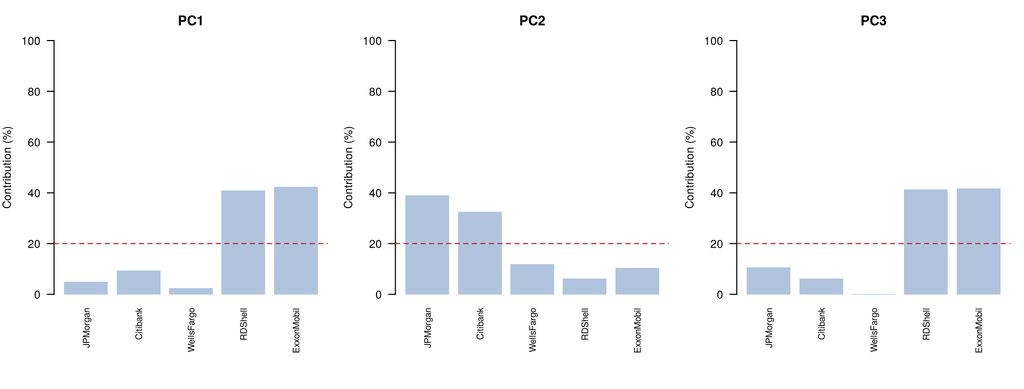

```r
par(mfrow = c(1, 3), mar = c(7, 4, 3, 1))
for (i in 1:3) {
  barplot(contrib[, i], las = 2, cex.names = 0.8, col = "lightsteelblue", border = NA,
          ylim = c(0, 100), ylab = "Contribution (%)", main = paste0("PC", i))
  abline(h = 100 / p, lty = 2, col = "firebrick")
}
```

```r
par(mfrow = c(1, 1))
```

- **$\hat y_1$:** Royal Dutch Shell (40.8%) và ExxonMobil (42.4%) chiếm tổng cộng 83.2%; ba ngân hàng đều dưới mức trung bình 20%.
- **$\hat y_2$:** JP Morgan (39.1%) và Citibank (32.5%) đóng góp nhiều nhất, Wells Fargo và hai cổ phiếu dầu khoảng 6–12% mỗi biến.
- **$\hat y_3$:** gần như chỉ do Royal Dutch Shell (41.3%) và ExxonMobil (41.7%).

Contribution chỉ dựa vào hệ số $\hat v_{ik}$ nên cho cùng thứ hạng với $|\hat v_{ik}|$; nó bổ sung cho tương quan ở trên ở chỗ cho biết phần trăm “cấu tạo” của từng thành phần.

#### 0.4.4.7 Chất lượng biểu diễn của từng biến (cos²)

Chất lượng biểu diễn của biến $x_k$ trên $\hat y_i$ là $\cos^2_{ik}=r^2_{\hat y_i,x_k}$. Bình phương hệ số tương quan $r^2_{\hat y_i,x_k}=\hat v_{ik}^2\hat\lambda_i/s_{kk}$ là tỷ lệ phương sai của biến $x_k$ được giải thích bởi $\hat y_i$. Vì $\sum_{i=1}^{5}\hat v_{ik}^2\hat\lambda_i$ chính là phần tử $s_{kk}$ của $\mathbf S=\hat{\mathbf V}\hat{\boldsymbol\Lambda}\hat{\mathbf V}'$, nên $\sum_{i=1}^{5}r^2_{\hat y_i,x_k}=1$ với mỗi biến $x_k$.

```r
r2_y_x <- r_y_x^2
bang(data.frame(Bien = colnames(X), round(r2_y_x, 3),
                Tong_y1_y2 = round(r2_y_x[, 1] + r2_y_x[, 2], 3),
                Tong_tat_ca = round(rowSums(r2_y_x), 3),
                row.names = NULL), digits = 3)
```

| Bien | y1 | y2 | y3 | y4 | y5 | Tong_y1_y2 | Tong_tat_ca |
| --- | --- | --- | --- | --- | --- | --- | --- |
| JPMorgan | 0.157 | 0.633 | 0.062 | 0.145 | 0.004 | 0.789 | 1 |
| Citibank | 0.294 | 0.520 | 0.036 | 0.056 | 0.094 | 0.814 | 1 |
| WellsFargo | 0.146 | 0.372 | 0.002 | 0.157 | 0.323 | 0.518 | 1 |
| RDShell | 0.773 | 0.060 | 0.145 | 0.019 | 0.004 | 0.833 | 1 |
| ExxonMobil | 0.757 | 0.095 | 0.138 | 0.009 | 0.001 | 0.852 | 1 |

- $\hat y_1$ giải thích khoảng 77% phương sai của Royal Dutch Shell và 76% của ExxonMobil, nhưng chỉ 15%–29% phương sai của từng ngân hàng.
- $\hat y_2$ giải thích phần lớn phần còn lại của nhóm ngân hàng: 63% của JP Morgan, 52% của Citibank, 37% của Wells Fargo.
- Gộp hai thành phần đầu, $\hat y_1$ và $\hat y_2$ giải thích khoảng 79%–85% phương sai của JP Morgan, Citibank, Royal Dutch Shell, ExxonMobil, nhưng chỉ khoảng 52% của Wells Fargo; phần lớn phần còn lại của Wells Fargo nằm ở $\hat y_5$ (32%). Tức là Wells Fargo có biến động riêng đáng kể mà hai thành phần chung chưa nắm bắt được.
- Cột cuối bằng 1 với mọi biến, đúng tính chất $\sum_i r^2_{\hat y_i,x_k}=1$.

**Nhận xét chung:** $\hat y_1$ tương quan dương với cả 5 cổ phiếu và mạnh nhất với nhóm dầu; $\hat y_2$ tương quan mạnh với nhóm ngân hàng và ngược dấu, yếu với nhóm dầu; $\hat y_3,\hat y_4$ chỉ tương quan yếu với từng biến, $\hat y_5$ chỉ tương quan mức trung bình với riêng Wells Fargo ($r\approx$ 0.57). Hệ số tương quan củng cố cách hiểu $\hat y_1$ là thành phần thị trường và $\hat y_2$ là thành phần ngành.

### 0.4.5 Ma trận hệ số tải (loadings)

Ma trận hệ số tải là ma trận $\hat{\mathbf V}=(\hat{\mathbf v}_1,\dots,\hat{\mathbf v}_5)$: cột thứ $i$ chứa các hệ số $\hat v_{ik}$ của biến $x_k$ trong thành phần chính $\hat y_i$. Hệ số tải cho biết mỗi biến đóng góp nhiều hay ít, cùng chiều hay ngược chiều vào từng thành phần chính.

```r
loadings <- V_hat
colnames(loadings) <- paste0("Comp.", 1:p)
round(loadings, 3)
```

```
##            Comp.1 Comp.2 Comp.3 Comp.4 Comp.5
## JPMorgan    0.223  0.625  0.326  0.663  0.118
## Citibank    0.307  0.570 -0.250 -0.414 -0.589
## WellsFargo  0.155  0.345 -0.038 -0.497  0.780
## RDShell     0.639 -0.248 -0.642  0.309  0.148
## ExxonMobil  0.651 -0.322  0.646 -0.216 -0.094
```

Cột `Comp.1` có 5 hệ số cùng dấu, lớn nhất ở RD Shell và ExxonMobil; cột `Comp.2` tách ba ngân hàng và hai cổ phiếu dầu thành hai nhóm ngược dấu.

#### 0.4.5.1 Barplot hệ số tải của hai thành phần chính đầu

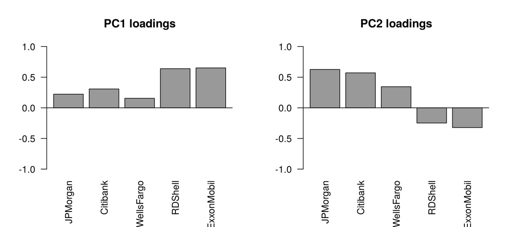

```r
par(mfrow = c(1, 2))
barplot(loadings[, 1], names.arg = colnames(X), las = 2, col = "grey60",
        ylim = c(-1, 1), main = "PC1 loadings")
abline(h = 0)
barplot(loadings[, 2], names.arg = colnames(X), las = 2, col = "grey60",
        ylim = c(-1, 1), main = "PC2 loadings")
abline(h = 0)
```

```r
par(mfrow = c(1, 1))
```

- **PC1:** cả 5 cột nằm cùng một phía của trục 0 → mọi cổ phiếu đóng góp cùng chiều vào $\hat y_1$; hai cột dầu (RDShell, ExxonMobil) cao nhất (≈ 0.64, 0.65), ba cột ngân hàng thấp hơn (≈ 0.15 – 0.31).
- **PC2:** ba cột ngân hàng nằm một phía, hai cột dầu nằm phía ngược lại → $\hat y_2$ là tương phản giữa ngành ngân hàng và ngành dầu; JP Morgan và Citibank có hệ số lớn nhất (≈ 0.63, 0.57).

#### 0.4.5.2 Đồ thị loading

Mỗi biến được biểu diễn bằng một điểm có tọa độ (hệ số tải trên PC1, hệ số tải trên PC2).

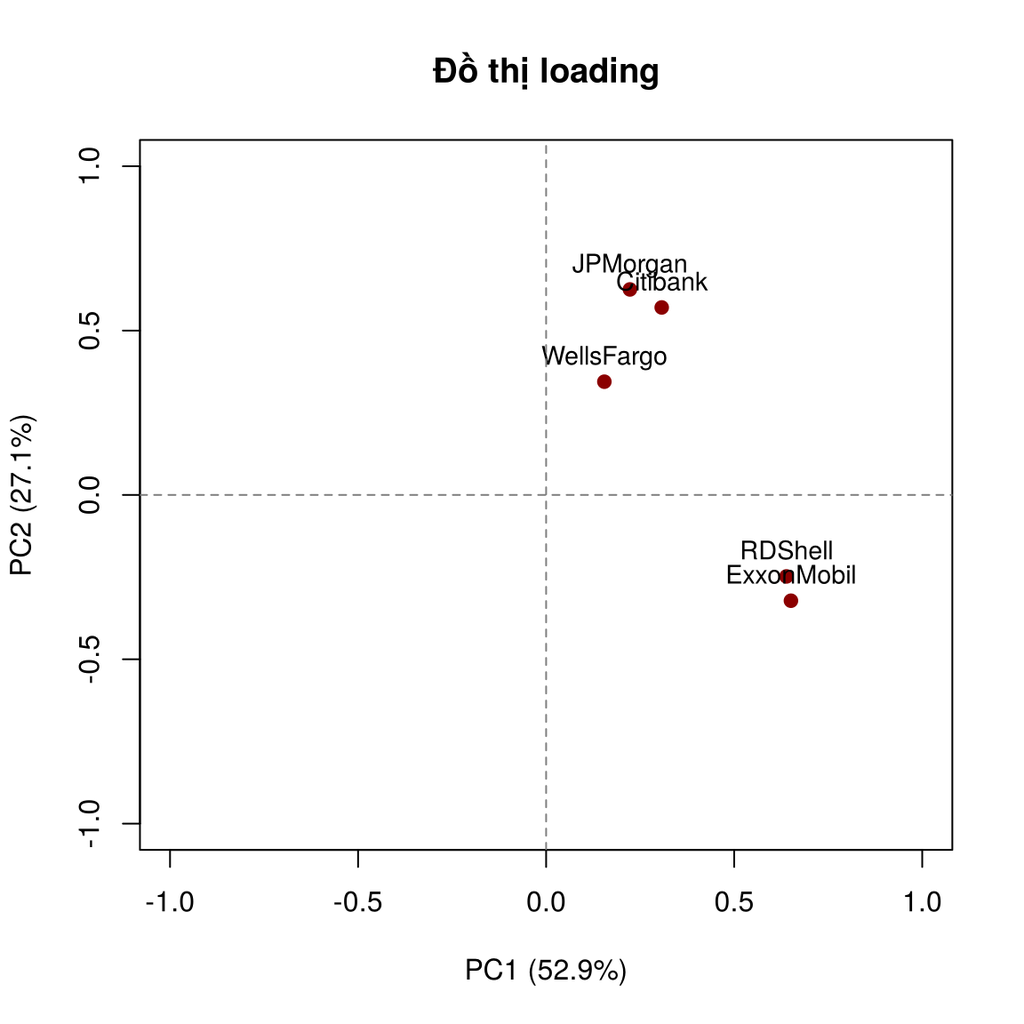

```r
plot(loadings[, 1], loadings[, 2], pch = 19, col = "darkred",
     xlim = c(-1, 1), ylim = c(-1, 1),
     xlab = paste0("PC1 (", round(100 * lambda_hat[1] / sum(lambda_hat), 1), "%)"),
     ylab = paste0("PC2 (", round(100 * lambda_hat[2] / sum(lambda_hat), 1), "%)"),
     main = "Đồ thị loading")
text(loadings[, 1], loadings[, 2], labels = colnames(X), pos = 3, cex = 0.9)
abline(h = 0, v = 0, lty = 2, col = "grey50")
```

Các biến tạo thành **hai cụm** tách biệt theo trục PC2: cụm ngân hàng (JPMorgan, Citibank, WellsFargo) và cụm dầu (RDShell, ExxonMobil). Trên trục PC1, cả 5 điểm nằm cùng một phía của 0, cụm dầu nằm xa gốc hơn. Các biến nằm gần nhau trên đồ thị là các biến tương quan mạnh với nhau — khớp với ma trận tương quan ở mục Ma trận tương quan mẫu R (ngân hàng tương quan với nhau, dầu tương quan với nhau, tương quan chéo thấp).

#### 0.4.5.3 Đồ thị score

Mỗi tuần được biểu diễn bằng một điểm (vòng tròn) có tọa độ $(\hat y_{j1},\hat y_{j2})$ (score trên PC1, PC2), nhãn bên cạnh là số thứ tự tuần.

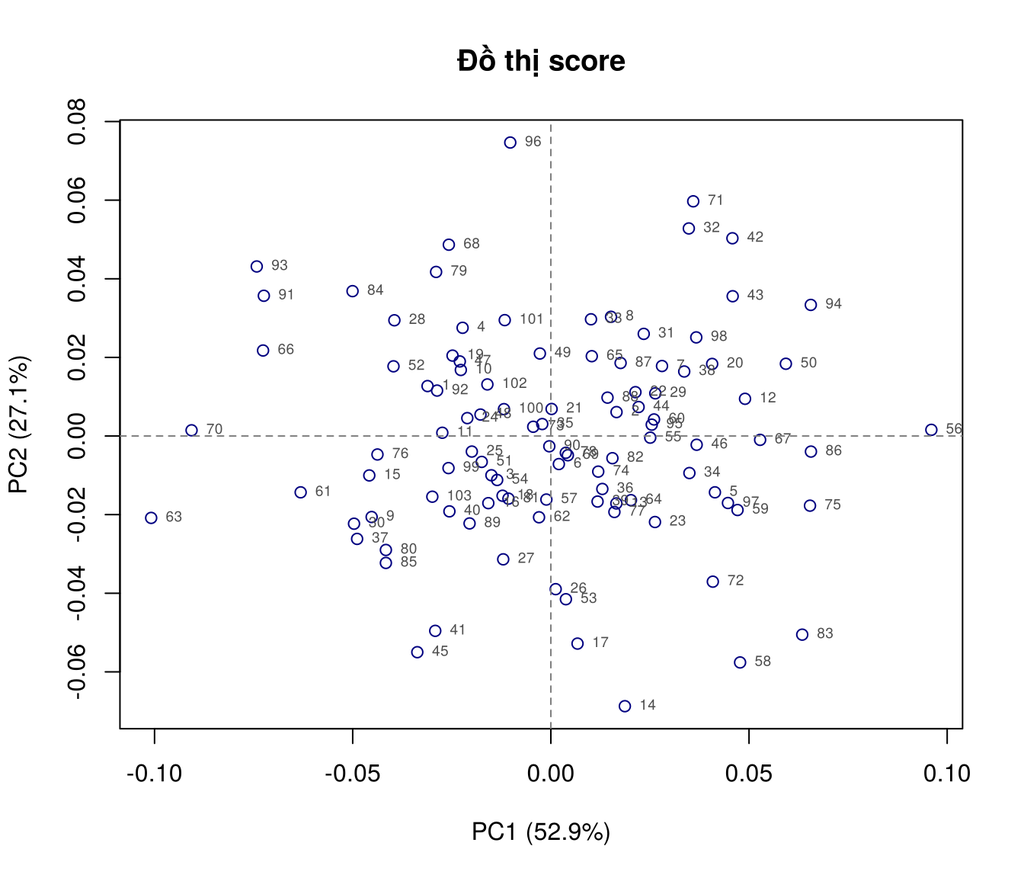

```r
plot(Y_hat[, 1], Y_hat[, 2], pch = 1, col = "navy",
     xlab = paste0("PC1 (", round(100 * lambda_hat[1] / sum(lambda_hat), 1), "%)"),
     ylab = paste0("PC2 (", round(100 * lambda_hat[2] / sum(lambda_hat), 1), "%)"),
     main = "Đồ thị score")
text(Y_hat[, 1], Y_hat[, 2], labels = 1:n, pos = 4, cex = 0.6, col = "grey30")
abline(h = 0, v = 0, lty = 2, col = "grey50")
```

```r
# các tuần có score cực trị trên PC1 và PC2
tuan_cuc_tri <- c(which.min(Y_hat[, 1]), which.max(Y_hat[, 1]),
                  which.min(Y_hat[, 2]), which.max(Y_hat[, 2]))
round(cbind(tuan = tuan_cuc_tri, X[tuan_cuc_tri, ], Y_hat[tuan_cuc_tri, 1:2]), 4)
```

```
##      tuan JPMorgan Citibank WellsFargo RDShell ExxonMobil      y1      y2
## [1,]   63  -0.0300  -0.0497    -0.0167 -0.0508    -0.0583 -0.1009 -0.0208
## [2,]   56   0.0188   0.0380     0.0155  0.0510     0.0784  0.0960  0.0016
## [3,]   14  -0.0459  -0.0278    -0.0143  0.0375     0.0332  0.0187 -0.0687
## [4,]   96   0.0257   0.0525     0.0407 -0.0317    -0.0188 -0.0102  0.0747
```

Các điểm phân tán quanh gốc (0, 0) — gốc ứng với một tuần có suất sinh lợi bằng trung bình — trải rộng theo trục PC1 hơn theo trục PC2 (vì $\hat\lambda_1>\hat\lambda_2$), không tách thành các nhóm rời nhau. Đọc theo hai trục:

- **Theo PC1 (thị trường):** tuần 63 và tuần 56 nằm ở hai đầu trục PC1. Bảng trên cho thấy ở tuần 63 cả 5 cổ phiếu cùng biến động mạnh theo một chiều, ở tuần 56 theo chiều ngược lại → điểm càng xa gốc theo PC1 là tuần thị trường chung biến động càng mạnh.
- **Theo PC2 (ngành):** tuần 14 và tuần 96 nằm ở hai đầu trục PC2. Ở các tuần này, nhóm ngân hàng và nhóm dầu đi ngược chiều nhau (một ngành tăng, ngành kia giảm) → điểm càng xa gốc theo PC2 là tuần mà hai ngành phân hóa càng mạnh.

#### 0.4.5.4 95% mật độ ellipsoid và các thành phần chính

Nếu ${\mathbf x}$ có phân phối chuẩn nhiều chiều thì $(\hat y_1,\hat y_2)$ xấp xỉ chuẩn với trung bình 0, không tương quan, phương sai $\hat\lambda_1,\hat\lambda_2$. Ellipse mật độ 95% trên mặt phẳng PC1–PC2 là tập các điểm thỏa

$$\frac{\hat
y_1^2}{\hat\lambda_1}+\frac{\hat
y_2^2}{\hat\lambda_2}\le\chi^2_2(0.95),$$

có tâm tại gốc, trục lớn theo hướng PC1 với nửa độ dài $\sqrt{\chi^2_2(0.95)\,\hat\lambda_1}$, trục nhỏ theo hướng PC2 với nửa độ dài $\sqrt{\chi^2_2(0.95)\,\hat\lambda_2}$. Hai mũi tên trên đồ thị là hai thành phần chính (hai trục của ellipse).

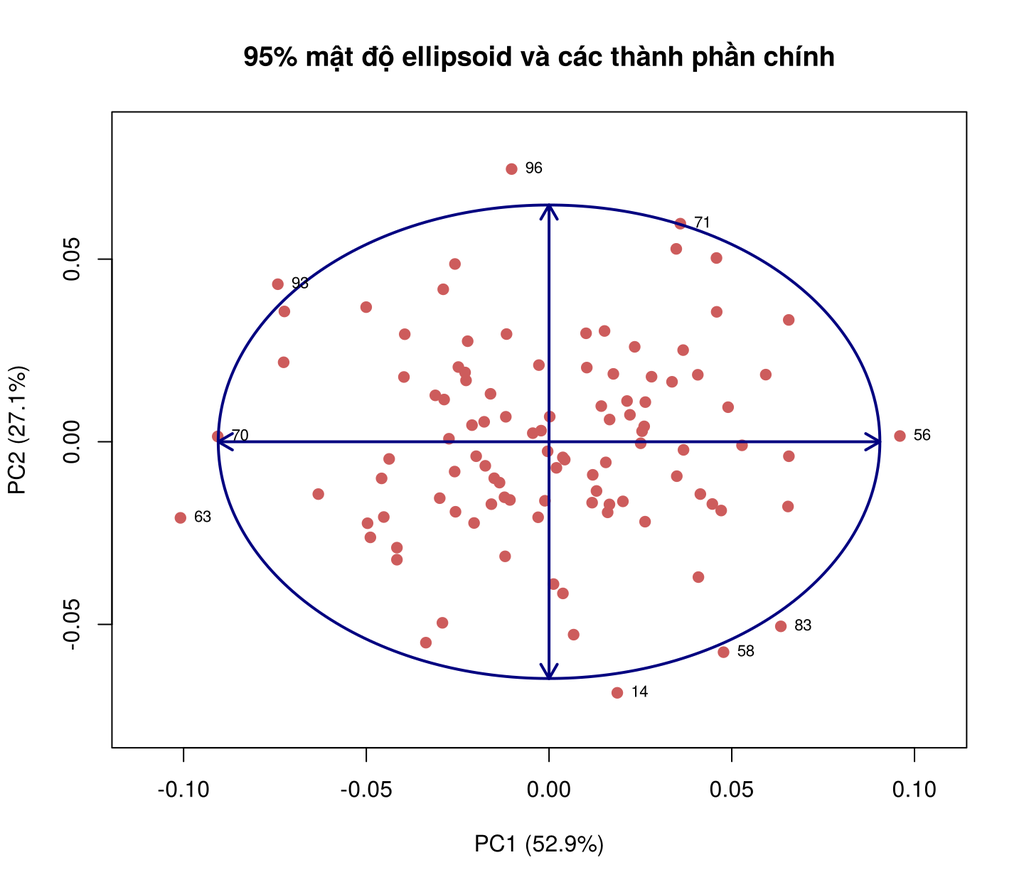

```r
chi2_95 <- qchisq(0.95, df = 2)
nua_truc_1 <- sqrt(chi2_95 * lambda_hat[1])
nua_truc_2 <- sqrt(chi2_95 * lambda_hat[2])
goc <- seq(0, 2 * pi, length.out = 300)

plot(Y_hat[, 1], Y_hat[, 2], pch = 19, col = "indianred", asp = 1,
     xlim = range(c(Y_hat[, 1], -nua_truc_1, nua_truc_1)) * 1.1,
     ylim = range(c(Y_hat[, 2], -nua_truc_2, nua_truc_2)) * 1.1,
     xlab = paste0("PC1 (", round(100 * lambda_hat[1] / sum(lambda_hat), 1), "%)"),
     ylab = paste0("PC2 (", round(100 * lambda_hat[2] / sum(lambda_hat), 1), "%)"),
     main = "95% mật độ ellipsoid và các thành phần chính")
lines(nua_truc_1 * cos(goc), nua_truc_2 * sin(goc), lwd = 2, col = "navy")
arrows(-nua_truc_1, 0, nua_truc_1, 0, code = 3, length = 0.12, lwd = 2, col = "navy")
arrows(0, -nua_truc_2, 0, nua_truc_2, code = 3, length = 0.12, lwd = 2, col = "navy")

# các tuần nằm ngoài ellipse 95%
d2_pc <- Y_hat[, 1]^2 / lambda_hat[1] + Y_hat[, 2]^2 / lambda_hat[2]
ngoai <- which(d2_pc > chi2_95)
text(Y_hat[ngoai, 1], Y_hat[ngoai, 2], labels = (1:n)[ngoai], pos = 4, cex = 0.7)
```

```r
c(nua_truc_1 = nua_truc_1, nua_truc_2 = nua_truc_2)
```

```
## nua_truc_1 nua_truc_2
## 0.09052290 0.06481491
```

```r
c(so_ngoai_ellipse = length(ngoai), ky_vong = 0.05 * n)
```

```
## so_ngoai_ellipse          ky_vong
##             9.00             5.15
```

```r
(1:n)[ngoai]
```

```
## [1] 14 56 58 63 70 71 83 93 96
```

Ellipse có tâm tại gốc (điểm trung bình), trục lớn nằm theo hướng PC1 với nửa độ dài 0.0905 và trục nhỏ theo hướng PC2 với nửa độ dài 0.0648; tỷ số hai trục $\sqrt{\hat\lambda_1/\hat\lambda_2}=$ 1.4 cho thấy dữ liệu trải rộng theo PC1 nhiều hơn theo PC2. Có 9 tuần nằm ngoài ellipse (14, 56, 58, 63, 70, 71, 83, 93, 96), so với khoảng 5.2 tuần kỳ vọng nếu dữ liệu chuẩn. Các tuần ngoài ellipse là những tuần thị trường hoặc hai ngành biến động mạnh (đã thấy ở hai đầu trục trong đồ thị score).

#### 0.4.5.5 Đồ thị biplot

Biplot vẽ chồng đồ thị score (các tuần, dạng số thứ tự) và đồ thị loading (các biến, dạng mũi tên từ gốc) trên cùng một hệ trục PC1–PC2. Trục dưới/trái là thang của score, trục trên/phải là thang của loading.

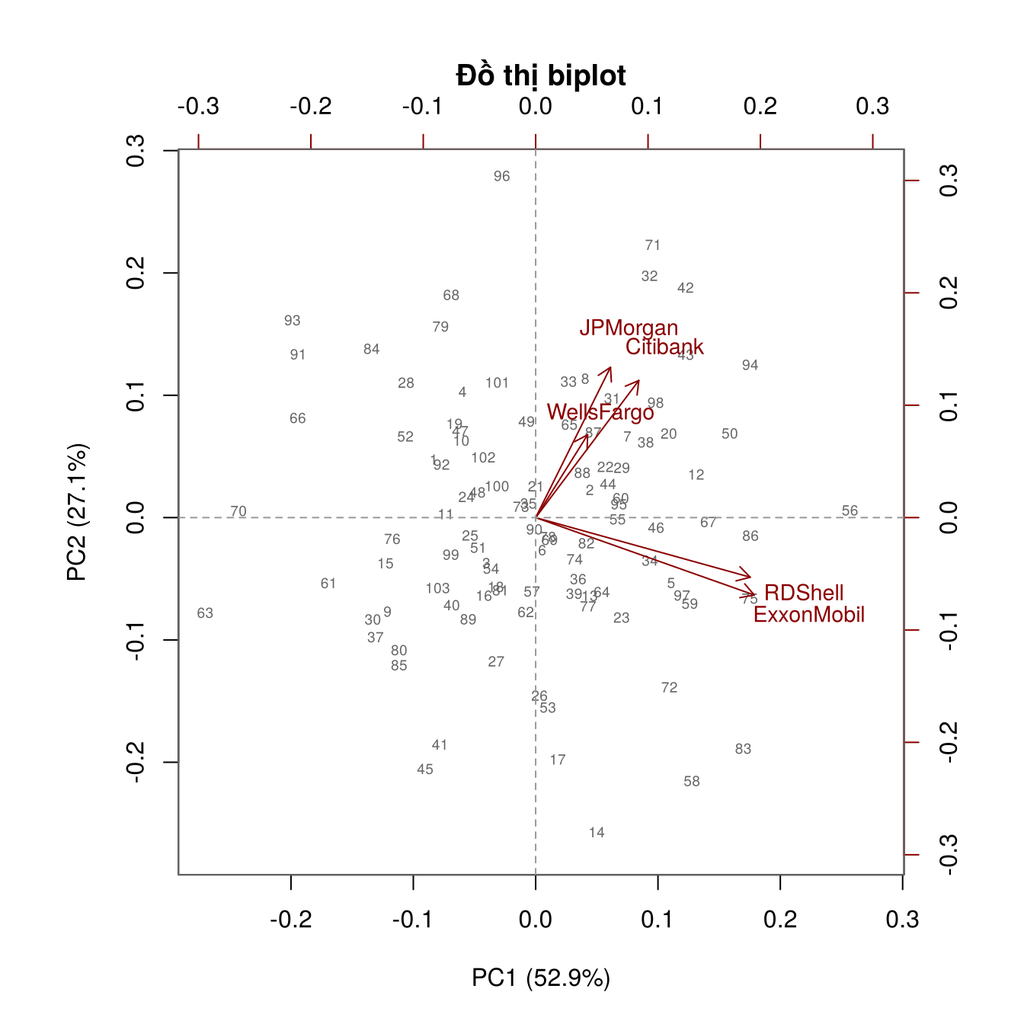

```r
pc_stock <- princomp(X, cor = FALSE)
biplot(pc_stock, choices = 1:2,
       col = c("grey40", "darkred"), cex = c(0.6, 0.9), expand = 0.8,
       xlab = paste0("PC1 (", round(100 * lambda_hat[1] / sum(lambda_hat), 1), "%)"),
       ylab = paste0("PC2 (", round(100 * lambda_hat[2] / sum(lambda_hat), 1), "%)"),
       main = "Đồ thị biplot")
abline(h = 0, v = 0, lty = 2, col = "grey60")
```

- **Mũi tên (biến):** ba mũi tên ngân hàng chụm lại một hướng, hai mũi tên dầu chụm lại hướng khác; góc giữa hai mũi tên càng nhỏ thì hai biến tương quan càng mạnh (xấp xỉ, vì biplot chỉ biểu diễn trên 2 thành phần đầu) → lại thấy hai nhóm ngân hàng và dầu. Mọi mũi tên đều có thành phần cùng chiều trên PC1 (thành phần thị trường), còn trên PC2 thì hai nhóm chỉ ngược chiều nhau (thành phần ngành).
- **Điểm (tuần) so với mũi tên:** tuần nằm xa gốc theo hướng của một mũi tên là tuần cổ phiếu đó có suất sinh lợi cao hơn trung bình; nằm ngược hướng là thấp hơn trung bình. Ví dụ tuần 56 nằm theo hướng chung của cả 5 mũi tên (cả 5 cổ phiếu cùng tăng mạnh), tuần 63 nằm ngược hướng (cả 5 cùng giảm mạnh); tuần 96 nằm về phía mũi tên ngân hàng (ngân hàng tăng, dầu giảm), tuần 14 nằm về phía mũi tên dầu (dầu tăng, ngân hàng giảm) — khớp với bảng ở đồ thị score.

**Kết luận câu (a):** Ma trận hiệp phương sai mẫu $\mathbf S$ như ở mục Vectơ trung bình mẫu và ma trận hiệp phương sai mẫu S. Năm thành phần chính mẫu là $\hat y_i=\hat{\mathbf v}_i'\mathbf x$, $i=1,\dots,5$, với hệ số cho ở mục Các thành phần chính mẫu và phương sai lần lượt $\hat\lambda_1=$ 0.001368, $\hat\lambda_2=$ 0.0007012, $\hat\lambda_3=$ 0.0002538, $\hat\lambda_4=$ 0.0001426, $\hat\lambda_5=$ 0.0001189; các thành phần chính đôi một không tương quan.

## 0.5 Câu (b) — Tỷ số đóng góp vào phương sai suy rộng của 3 thành phần chính đầu

### 0.5.1 Tính tỷ số đóng góp

Phương sai suy rộng (tổng phương sai mẫu) $=\text{tr}(\mathbf S)=\sum_{k}s_{kk}=\hat\lambda_1+\dots+\hat\lambda_5$. Tỷ số đóng góp của thành phần chính thứ $i$ là $\hat\lambda_i/\sum_k\hat\lambda_k$; tỷ lệ tích lũy của $q$ thành phần đầu là $r_q=\sum_{k=1}^q\hat\lambda_k/\sum_{k=1}^p\hat\lambda_k$.

```r
tong_phuong_sai <- sum(diag(S))
c(trace_S = tong_phuong_sai, tong_lambda = sum(lambda_hat))
```

```
##     trace_S tong_lambda
## 0.002584129 0.002584129
```

```r
ty_le     <- lambda_hat / sum(lambda_hat)
ty_le_tich_luy <- cumsum(lambda_hat) / sum(lambda_hat)

bang_ty_le <- data.frame(
  TPC = paste0("y", 1:p),
  lambda_hat = lambda_hat,
  Ty_le = round(ty_le, 4),
  Tich_luy = round(ty_le_tich_luy, 4)
)
bang(bang_ty_le, digits = 7)
```

| TPC | lambda_hat | Ty_le | Tich_luy |
| --- | --- | --- | --- |
| y1 | 0.0013677 | 0.5293 | 0.5293 |
| y2 | 0.0007012 | 0.2713 | 0.8006 |
| y3 | 0.0002538 | 0.0982 | 0.8988 |
| y4 | 0.0001426 | 0.0552 | 0.9540 |
| y5 | 0.0001189 | 0.0460 | 1.0000 |

$\text{tr}(\mathbf S)=$ 0.0025841 $=\sum\hat\lambda_k$. Cụ thể:

- $\hat y_1$: $\dfrac{\hat\lambda_1}{\sum\hat\lambda_k}=\dfrac{0.0013677}{0.0025841}=$ 52.93%
- $\hat y_2$: 27.13%; $\hat y_3$: 9.82%
- **Ba thành phần đầu:** $r_3=\dfrac{\hat\lambda_1+\hat\lambda_2+\hat\lambda_3}{\sum_{k=1}^5\hat\lambda_k}=$ **89.88%** (hai thành phần đầu: $r_2=$ 80.06%).

### 0.5.2 Scree-plot

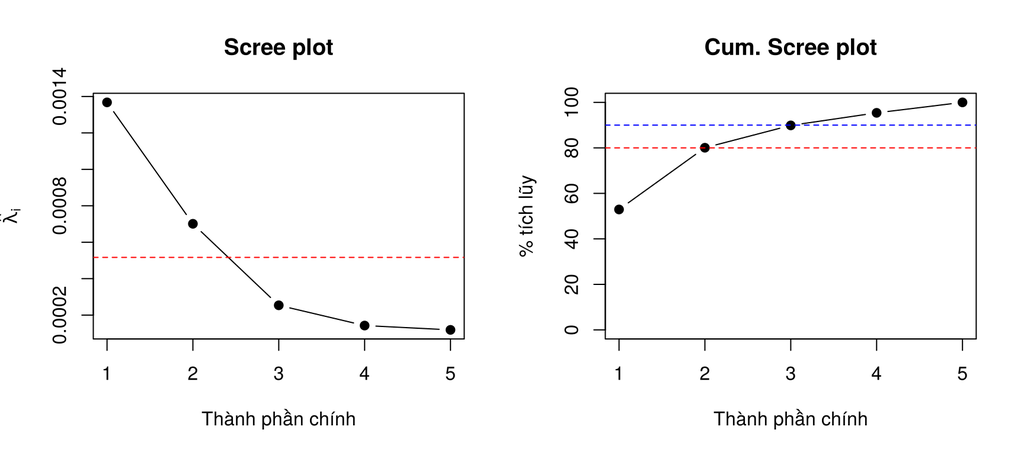

```r
par(mfrow = c(1, 2))
plot(1:p, lambda_hat, type = "b", pch = 19, xlab = "Thành phần chính", ylab = expression(hat(lambda)[i]),
     main = "Scree plot")
abline(h = mean(lambda_hat), col = "red", lty = 2)          # trung bình các trị riêng
plot(1:p, 100 * ty_le_tich_luy, type = "b", pch = 19, ylim = c(0, 100),
     xlab = "Thành phần chính", ylab = "% tích lũy", main = "Cum. Scree plot")
abline(h = c(80, 90), col = c("red", "blue"), lty = 2)
```

```r
par(mfrow = c(1, 1))
```

Scree plot giảm mạnh từ $\hat\lambda_1$ đến $\hat\lambda_2$ và $\hat\lambda_3$, sau đó gần như nằm ngang từ $\hat\lambda_3$ đến $\hat\lambda_5$ → “khuỷu tay” ở thành phần thứ 3. Đường đỏ (giá trị trung bình $\bar\lambda$) chỉ có $\hat\lambda_1,\hat\lambda_2$ nằm trên. Đường tích lũy vượt 80% tại $q=2$ và gần chạm 90% tại $q=3$.

### 0.5.3 Ý nghĩa của ba thành phần chính đầu

```r
bang(data.frame(Bien = colnames(X), V_hat[, 1:3], row.names = NULL), digits = 3)
```

| Bien | v1 | v2 | v3 |
| --- | --- | --- | --- |
| JPMorgan | 0.223 | 0.625 | 0.326 |
| Citibank | 0.307 | 0.570 | -0.250 |
| WellsFargo | 0.155 | 0.345 | -0.038 |
| RDShell | 0.639 | -0.248 | -0.642 |
| ExxonMobil | 0.651 | -0.322 | 0.646 |

- **$\hat y_1$ – thành phần thị trường.** Cả 5 hệ số cùng dấu, nên $\hat y_1$ là một “chỉ số” có trọng số của cả 5 cổ phiếu: khi thị trường chung đi lên/xuống thì cả 5 cùng đi lên/xuống. Do dùng $\mathbf S$ (không chuẩn hóa), hai cổ phiếu dầu có phương sai lớn nhận trọng số lớn nhất (0.639, 0.651), ba ngân hàng trọng số nhỏ hơn. $\hat y_1$ giải thích 52.9% phương sai suy rộng.
- **$\hat y_2$ – thành phần ngành.** Ba cổ phiếu ngân hàng có hệ số cùng dấu (0.625, 0.57, 0.345), hai cổ phiếu dầu có hệ số ngược dấu (-0.248, -0.322) → $\hat y_2$ là **sự tương phản giữa nhóm ngân hàng và nhóm dầu lửa**, đo việc một ngành tăng tương đối so với ngành kia. Giải thích thêm 27.1%.
- **$\hat y_3$ – tương phản bên trong ngành dầu.** Hệ số lớn nhất về trị tuyệt đối là của Royal Dutch Shell (-0.642) và ExxonMobil (0.646), ngược dấu nhau → $\hat y_3$ chủ yếu đo **sự khác biệt giữa hai cổ phiếu dầu**, kèm một tương phản nhỏ JP Morgan – Citibank. Chỉ giải thích 9.8%.

**Kết luận câu (b):** Ba thành phần chính mẫu đầu tiên có tỷ số đóng góp vào phương sai suy rộng lần lượt là 52.93%, 27.13%, 9.82%, tổng cộng **89.88%**. Nghĩa là ba tổ hợp tuyến tính $\hat y_1,\hat y_2,\hat y_3$ (thị trường, ngành ngân hàng–dầu, khác biệt giữa hai cổ phiếu dầu) giữ lại khoảng 90% toàn bộ biến thiên của suất sinh lợi 5 cổ phiếu; phần còn lại (~10.1%) là biến thiên riêng lẻ của từng cổ phiếu.

## 0.6 Câu (c) — Khoảng tin cậy đồng thời Bonferroni 90% cho λ₁, λ₂, λ₃

### 0.6.1 Công thức

Giả thiết: $\mathbf X_1,\dots,\mathbf X_{103}$ là mẫu ngẫu nhiên từ $N_5(\boldsymbol\mu,\boldsymbol\Sigma)$ (mục Giả định chuẩn nhiều chiều), $\boldsymbol\Sigma$ xác định dương với các trị riêng phân biệt $\lambda_1>\lambda_2>\dots>\lambda_5>0$, và $n=103$ lớn. Khi đó $\hat\lambda_i$ xấp xỉ $N(\lambda_i,2\lambda_i^2/n)$ và độc lập nhau, cho khoảng tin cậy độ tin cậy $\gamma$:

$$\frac{\hat\lambda_i}{1+z_{(1+\gamma)/2}\sqrt{2/n}}\le\lambda_i\le\frac{\hat\lambda_i}{1-z_{(1+\gamma)/2}\sqrt{2/n}},$$

trong đó $z_{(1+\gamma)/2}$ là phân vị của phân phối $N(0,1)$ ở mức xác suất $(1+\gamma)/2$.

**Bonferroni cho $m$ trị riêng:** để $m$ khoảng đúng đồng thời với độ tin cậy ít nhất $\gamma$, mỗi khoảng được xây dựng ở độ tin cậy $\gamma^*=1-\frac{1-\gamma}{m}$, tức thay phân vị $z_{(1+\gamma)/2}$ bằng $z_{(1+\gamma^*)/2}=z_{1-\frac{1-\gamma}{2m}}$.

Ở đây $\gamma=0.90$, $m=3$: $\gamma^*=1-0.1/3$, phân vị cần dùng là $z_{1-0.1/6}=z_{0.98333}$.

### 0.6.2 Tính toán

```r
gamma <- 0.90
m <- 3
muc_phan_vi <- 1 - (1 - gamma) / (2 * m)
z_bonf <- qnorm(muc_phan_vi)
c(muc_phan_vi = muc_phan_vi, z = z_bonf)
```

```
## muc_phan_vi           z
##   0.9833333   2.1280452
```

```r
can_duoi <- lambda_hat[1:m] / (1 + z_bonf * sqrt(2 / n))
can_tren <- lambda_hat[1:m] / (1 - z_bonf * sqrt(2 / n))

bang_ci <- data.frame(
  Tri_rieng = paste0("lambda_", 1:m),
  lambda_hat = lambda_hat[1:m],
  Can_duoi = can_duoi,
  Can_tren = can_tren
)
bang(bang_ci, digits = 7)
```

| Tri_rieng | lambda_hat | Can_duoi | Can_tren |
| --- | --- | --- | --- |
| lambda_1 | 0.0013677 | 0.0010549 | 0.0019442 |
| lambda_2 | 0.0007012 | 0.0005408 | 0.0009967 |
| lambda_3 | 0.0002538 | 0.0001958 | 0.0003608 |

$z_{0.98333}=$ 2.128, $\sqrt{2/n}=\sqrt{2/103}=$ 0.1393, nên $z\sqrt{2/n}=$ 0.2965 < 1 (mẫu số cận trên dương, công thức dùng được). Cụ thể:

- $\lambda_1$: $\dfrac{0.0013677}{1+0.2965}\le\lambda_1\le\dfrac{0.0013677}{1-0.2965}$ ⟹ **(0.001055; 0.001944)**
- $\lambda_2$: **(0.0005408; 0.0009967)**
- $\lambda_3$: **(0.0001958; 0.0003608)**

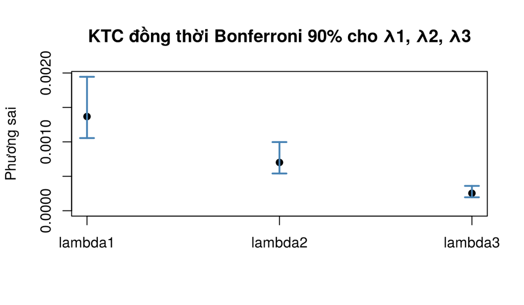

```r
plot(1:m, lambda_hat[1:m], ylim = c(0, max(can_tren)), pch = 19, xaxt = "n",
     xlab = "", ylab = "Phương sai", main = "KTC đồng thời Bonferroni 90% cho λ1, λ2, λ3")
axis(1, at = 1:m, labels = c("lambda1", "lambda2", "lambda3"))
arrows(1:m, can_duoi, 1:m, can_tren, angle = 90, code = 3, length = 0.08, col = "steelblue", lwd = 2)
```

Ba khoảng **không chồng lên nhau** (cận dưới của $\lambda_1$ > cận trên của $\lambda_2$; cận dưới của $\lambda_2$ > cận trên của $\lambda_3$) → với độ tin cậy ít nhất xấp xỉ 90%, $\lambda_1>\lambda_2>\lambda_3$ thực sự khác nhau. Các khoảng khá rộng (độ rộng tăng cùng tốc độ với $\hat\lambda_i$), nên cần thận trọng khi quyết định giữ hay bỏ thành phần chính chỉ dựa trên các giá trị $\hat\lambda_i$.

**Kết luận câu (c):** Với độ tin cậy đồng thời **ít nhất xấp xỉ 90%** (xấp xỉ vì dựa trên phân phối mẫu lớn và giả định chuẩn ở mục Giả định chuẩn nhiều chiều), ta có đồng thời $0.001055\le\lambda_1\le0.001944$, $\ 0.0005408\le\lambda_2\le0.0009967$, $\ 0.0001958\le\lambda_3\le0.0003608$.

## 0.7 Câu (d) — Có thể thu gọn dữ liệu xuống ít hơn 5 chiều không?

### 0.7.1 Ý nghĩa của từng thành phần chính

Để quyết định giữ bao nhiêu chiều, cần biết mỗi thành phần chính đại diện cho yếu tố gì. Ta đọc đồng thời hệ số $\hat v_{ik}$ (trọng số của biến $x_k$ trong $\hat y_i$) và tương quan $r_{\hat y_i,x_k}$ (mức độ $\hat y_i$ đại diện cho biến $x_k$):

```r
bang(data.frame(Bien = colnames(X), V_hat, row.names = NULL), digits = 3)
```

| Bien | v1 | v2 | v3 | v4 | v5 |
| --- | --- | --- | --- | --- | --- |
| JPMorgan | 0.223 | 0.625 | 0.326 | 0.663 | 0.118 |
| Citibank | 0.307 | 0.570 | -0.250 | -0.414 | -0.589 |
| WellsFargo | 0.155 | 0.345 | -0.038 | -0.497 | 0.780 |
| RDShell | 0.639 | -0.248 | -0.642 | 0.309 | 0.148 |
| ExxonMobil | 0.651 | -0.322 | 0.646 | -0.216 | -0.094 |

```r
bang(data.frame(Bien = colnames(X), r_y_x, row.names = NULL), digits = 3)
```

| Bien | y1 | y2 | y3 | y4 | y5 |
| --- | --- | --- | --- | --- | --- |
| JPMorgan | 0.396 | 0.795 | 0.250 | 0.380 | 0.062 |
| Citibank | 0.543 | 0.721 | -0.190 | -0.236 | -0.306 |
| WellsFargo | 0.383 | 0.610 | -0.040 | -0.397 | 0.569 |
| RDShell | 0.879 | -0.244 | -0.381 | 0.137 | 0.060 |
| ExxonMobil | 0.870 | -0.308 | 0.372 | -0.093 | -0.037 |

| TPC | Tỷ lệ phương sai | Cấu trúc hệ số | Ý nghĩa |
| --- | --- | --- | --- |
| $\hat y_1$ | 52.93% | Cả 5 hệ số cùng dấu; dầu (0.64, 0.65) lớn hơn ngân hàng (0.22, 0.31, 0.15) | **Thành phần thị trường**: biến động chung của cả 5 cổ phiếu theo tình hình kinh tế/thị trường. Tương quan với cả 5 biến đều dương (0.38 – 0.88) |
| $\hat y_2$ | 27.13% | Ngân hàng (0.63, 0.57, 0.34) ngược dấu với dầu (-0.25, -0.32) | **Thành phần ngành**: tuần mà cổ phiếu ngân hàng tăng mạnh hơn cổ phiếu dầu (hoặc ngược lại). Là yếu tố chính của nhóm ngân hàng (tương quan 0.61 – 0.80) |
| $\hat y_3$ | 9.82% | RD Shell (-0.64) ngược dấu ExxonMobil (0.65) | **Khác biệt giữa hai cổ phiếu dầu**: biến động riêng của từng công ty dầu, không phải của cả ngành |
| $\hat y_4$ | 5.52% | JP Morgan (0.66) ngược dấu Citibank (-0.41) và Wells Fargo (-0.50) | **Khác biệt giữa JP Morgan và hai ngân hàng còn lại**: biến động riêng của JP Morgan |
| $\hat y_5$ | 4.6% | Wells Fargo (0.78) ngược dấu Citibank (-0.59) | **Khác biệt giữa Wells Fargo và Citibank**: biến động riêng của hai ngân hàng này |

Như vậy chỉ $\hat y_1$ và $\hat y_2$ phản ánh các yếu tố **chung** (thị trường, ngành) tác động lên nhiều cổ phiếu cùng lúc; $\hat y_3,\hat y_4,\hat y_5$ chỉ là các **tương phản giữa từng cặp công ty** — biến thiên riêng của từng cổ phiếu, mỗi thành phần chỉ tương quan đáng kể với một, hai biến.

Diễn giải cụ thể từng thành phần:

- **$\hat y_1$ (thị trường).** Năm hệ số cùng dấu và năm tương quan đều dương, mạnh nhất với Royal Dutch Shell và ExxonMobil (0.88, 0.87), mức trung bình với ba ngân hàng. Các biến nổi bật không chia thành nhóm đối lập, nên $\hat y_1$ là hướng biến thiên **chung** của cả thị trường. Tuần có điểm $\hat y_1$ cao là tuần cả 5 cổ phiếu cùng có suất sinh lợi cao hơn trung bình (nổi bật nhất là cổ phiếu dầu); tuần có điểm thấp là tuần cả 5 cùng giảm.
- **$\hat y_2$ (ngành).** Biến nổi bật chia thành hai nhóm ngược dấu: ba ngân hàng (tương quan 0.61 – 0.80) và hai cổ phiếu dầu (-0.24, -0.31). $\hat y_2$ vì vậy không đo mức tăng/giảm chung mà **phân biệt hai ngành**. Tuần có điểm $\hat y_2$ cao là tuần cổ phiếu ngân hàng tăng mạnh hơn (hoặc giảm ít hơn) cổ phiếu dầu; điểm thấp là ngược lại.
- **$\hat y_3$ (khác biệt trong ngành dầu).** Hai biến nổi bật là Royal Dutch Shell (-0.64) và ExxonMobil (0.65), cùng ngành nhưng ngược dấu, các tương quan đều dưới 0.4. Tuần có điểm $\hat y_3$ cao là tuần hai cổ phiếu dầu đi lệch nhau theo một chiều (cổ phiếu có hệ số dương tăng hơn cổ phiếu có hệ số âm), tức biến động riêng của từng công ty dầu.
- **$\hat y_4$ (JP Morgan so với hai ngân hàng còn lại).** JP Morgan (0.66) ngược dấu với Citibank (-0.41) và Wells Fargo (-0.50); tuần có điểm $\hat y_4$ cao là tuần JP Morgan khác biệt so với hai ngân hàng kia theo chiều của hệ số.
- **$\hat y_5$ (Wells Fargo so với Citibank).** Wells Fargo (0.78) ngược dấu Citibank (-0.59); đây là thành phần duy nhất từ $\hat y_3$ trở đi có tương quan mức trung bình với một biến (Wells Fargo, $r\approx$ 0.57), cho thấy Wells Fargo có biến động riêng đáng kể.

### 0.7.2 Chọn số thành phần chính

```r
lambda_tb <- mean(lambda_hat)                    # trung bình các trị riêng
data.frame(
  q = 1:p,
  lambda_hat = signif(lambda_hat, 4),
  Tich_luy_phan_tram = round(100 * ty_le_tich_luy, 2),
  Lambda_lon_hon_TB = lambda_hat > lambda_tb
)
```

```
##   q lambda_hat Tich_luy_phan_tram Lambda_lon_hon_TB
## 1 1  0.0013680              52.93              TRUE
## 2 2  0.0007012              80.06              TRUE
## 3 3  0.0002538              89.88             FALSE
## 4 4  0.0001426              95.40             FALSE
## 5 5  0.0001189             100.00             FALSE
```

```r
lambda_tb
```

```
## [1] 0.0005168259
```

1. **Tỷ lệ phương sai tích lũy:** cần 2 thành phần để đạt 70%, 2 thành phần để đạt 80% ($r_2=$ 80.06%) và 4 thành phần để đạt 90% ($r_3=$ 89.88%, sát ngưỡng 90%; $r_4=$ 95.4%). Với ngưỡng thường dùng 80% → giữ 2 thành phần.
2. **Scree-plot:** đường cong dốc từ $\hat\lambda_1$ đến $\hat\lambda_3$, sau đó gần như nằm ngang ($\hat\lambda_3,\hat\lambda_4,\hat\lambda_5$ nhỏ và gần bằng nhau) → khuỷu tay ở thành phần thứ 3; giữ các thành phần trên đoạn dốc trước khuỷu tay là 2 thành phần, nếu tính cả điểm khuỷu tay là 3.
3. **Tiêu chuẩn Kaiser** (giữ $\hat\lambda_q>\bar\lambda$): $\bar\lambda=$ 0.0005168; chỉ $\hat\lambda_1,\hat\lambda_2>\bar\lambda$ → giữ 2 thành phần.
4. **Câu (c):** ba khoảng tin cậy không chồng lên nhau → $\lambda_1,\lambda_2,\lambda_3$ khác nhau thực sự, nên $\hat y_1,\hat y_2,\hat y_3$ là các thành phần phân biệt (độ chính xác của vectơ riêng $\hat{\mathbf v}_i$ phụ thuộc vào mức khác biệt giữa các trị riêng; trị riêng tách biệt thì hướng $\hat{\mathbf v}_i$ ổn định). Các khoảng khá rộng nên quyết định giữ hay bỏ thành phần không dựa riêng vào $\hat\lambda_i$ mà kết hợp các tiêu chí 1–3 và ý nghĩa ở mục Ý nghĩa của từng thành phần chính.
5. **Ý nghĩa (mục Ý nghĩa của từng thành phần chính):** hai thành phần đầu là yếu tố chung có cách hiểu rõ ràng (thị trường, ngành); ba thành phần sau là biến thiên riêng của từng cặp công ty.

### 0.7.3 Kết luận

**Kết luận câu (d):** **Có**, dữ liệu suất sinh lợi 5 cổ phiếu có thể thu gọn xuống ít hơn 5 chiều. Giữ **2 thành phần chính** là đủ:

- $\hat y_1$ — **thành phần thị trường** (biến động chung của cả 5 cổ phiếu), và
- $\hat y_2$ — **thành phần ngành** (tương phản ngân hàng – dầu lửa),

giải thích 80.1% phương sai suy rộng, thỏa ngưỡng 80% và tiêu chuẩn Kaiser; khoảng tin cậy ở câu (c) cho thấy $\lambda_1,\lambda_2$ lớn hơn thực sự so với $\lambda_3$. Nói cách khác, phần lớn biến thiên của suất sinh lợi 5 cổ phiếu trong giai đoạn 2004–2005 được giải thích bởi **hoạt động của thị trường chung** và **hoạt động riêng của từng ngành** (hai yếu tố không tương quan với nhau). Nếu muốn giữ khoảng 90% biến thiên (theo scree-plot), có thể dùng **3 chiều** ($r_3=$ 89.9%), thêm thành phần khác biệt giữa hai cổ phiếu dầu. Hai thành phần cuối ($\hat y_4,\hat y_5$, tổng cộng 10.1%) chỉ là biến thiên riêng của từng ngân hàng, có thể bỏ.

Hạn chế: hai thành phần giữ lại biểu diễn tốt bốn cổ phiếu (khoảng 79%–85% phương sai của mỗi biến, mục Hệ số tương quan giữa thành phần chính và biến gốc) nhưng chỉ khoảng 52% phương sai của Wells Fargo; phần lớn biến động riêng của Wells Fargo nằm ở $\hat y_5$ và bị bỏ đi khi thu gọn xuống 2 chiều.